# thursday_08_27_2020

## Generating random numbers

We will use the `random` module or library.

```python
import random
```

```python
%whos
```

```
Variable   Type      Data/Info
------------------------------
random     module    <module 'random' from 'C:<...>s\\py38\\lib\\random.py'>
```

Fixing the random *seed*.

```python
random.seed(10)
```

```python
random.random()
```

```
0.5714025946899135
```

```python
random.random()
```

```
0.4288890546751146
```

```python
random.seed(10)
```

```python
print( random.random() )

print( random.random() )
```

```
0.5714025946899135
0.4288890546751146
```

Assign the result of our `random.random()` call to objects.

```python
random.seed(20)

x_a = [ random.random(), random.random() ]

random.seed(20)

x_b = [ random.random(), random.random() ]
```

```python
%whos
```

```
Variable   Type      Data/Info
------------------------------
random     module    <module 'random' from 'C:<...>s\\py38\\lib\\random.py'>
x_a        list      n=2
x_b        list      n=2
```

```python
print( x_a == x_b )
```

```
True
```

```python
print( x_a )

print( x_b )
```

```
[0.9056396761745207, 0.6862541570267026]
[0.9056396761745207, 0.6862541570267026]
```

```python
# BUT these are NOT the same OBJECTS

x_a is x_b
```

```
False
```

## Generate multiple random numbers

We will iterate and call `random.random()` programmatically many, many, many times. We will assign the result to a list.

### Use a for-loop and `.append()` method

```python
random.seed(11) # set the seed

xu = [] # initialize the list

print( len(xu) )

for ix in range(7):
    xu.append( random.random() )
```

```
0
```

```python
print( len(xu) )
```

```
7
```

```python
print( xu )
```

```
[0.4523795535098186, 0.559772386080496, 0.9242105840237294, 0.4656500700997733, 0.5078412730622711, 0.587384828849897, 0.18466034385487662]
```

```python
%whos
```

```
Variable   Type      Data/Info
------------------------------
ix         int       6
random     module    <module 'random' from 'C:<...>s\\py38\\lib\\random.py'>
x_a        list      n=2
x_b        list      n=2
xu         list      n=7
```

```python
for n in range(0, 4):
    print( n )
print( n )
```

```
0
1
2
3
3
```

```python
for n2 in range(4):
    print( n2 )
print(n2)
```

```
0
1
2
3
3
```

```python
for n1 in range(4):
    for n2 in ['a', 'b', 'c']:
        print( n1 )
        print( n2 )
    print('*--*')
print( n1 )
print( n2 )
```

```
0
a
0
b
0
c
*--*
1
a
1
b
1
c
*--*
2
a
2
b
2
c
*--*
3
a
3
b
3
c
*--*
3
c
```

### List comprehensions

```python
# structure of a list comprehension

# <output> = [ <action to perform iterating over a variable> for <variable> in <sequence> ]
```

```python
random.seed(11) # setting the seed

xu_b = [ random.random() for _ in range(7) ]
```

```python
print( xu_b )
```

```
[0.4523795535098186, 0.559772386080496, 0.9242105840237294, 0.4656500700997733, 0.5078412730622711, 0.587384828849897, 0.18466034385487662]
```

```python
# confirm that `xu` and `xu_b` are the SAME VALUES

print( xu == xu_b )
```

```
True
```

## Calculate the average

The average of $N$ observations of the variables $x_n$ where $n=1,...,N$:

$$ \bar{x} = \frac{1}{N} \sum_{n=1}^{N} \left( x_n \right) $$

```python
print( sum( [1, 2, 3] ) )
```

```
6
```

```python
print( len([1, 2, 3] ) )
```

```
3
```

```python
print( sum([1,2,3]) / len([1, 2, 3]))
```

```
2.0
```

### create a function to calculate the average

We will assume the values are in a list and they are integers or floats.

```python
def my_avg(x):
    """
    calculate the average of a list of integers or floats
    """
    return sum(x) / len(x)
```

```python
%whos
```

```
Variable   Type        Data/Info
--------------------------------
ix         int         6
my_avg     function    <function my_avg at 0x0000015D408F10D0>
n          int         3
n1         int         3
n2         str         c
random     module      <module 'random' from 'C:<...>s\\py38\\lib\\random.py'>
x_a        list        n=2
x_b        list        n=2
xu         list        n=7
xu_b       list        n=7
```

```python
my_avg( [1, 2, 3] )
```

```
2.0
```

```python
my_avg( [1.0, 2.0, 3.0] )
```

```
2.0
```

```python
my_avg()
```

```
---------------------------------------------------------------------------
TypeError                                 Traceback (most recent call last)
<ipython-input-33-f1313df81be0> in <module>
----> 1 my_avg()

TypeError: my_avg() missing 1 required positional argument: 'x'
```

```python
my_avg(['aol', 'yahoo', 'gmail'])
```

```
---------------------------------------------------------------------------
TypeError                                 Traceback (most recent call last)
<ipython-input-34-e1cfcd39f6dc> in <module>
----> 1 my_avg(['aol', 'yahoo', 'gmail'])

<ipython-input-29-cf00ba3d0f8d> in my_avg(x)
      3     calculate the average of a list of integers or floats
      4     """
----> 5     return sum(x) / len(x)

TypeError: unsupported operand type(s) for +: 'int' and 'str'
```

### Apply our average function

```python
random.seed(21)

yu = [ random.random() for _ in range(7) ]

zu = [ random.random() for _ in range(7) ]
```

```python
print( yu == zu )
```

```
False
```

```python
# do that action again

random.seed(21)

yu_b = [ random.random() for _ in range(7) ]

zu_b = [ random.random() for _ in range(7) ]
```

```python
print( yu == yu_b )

print( zu == zu_b )
```

```
True
True
```

```python
print( yu )

print( zu )
```

```
[0.16494947983319797, 0.6897669242175674, 0.6349999404047206, 0.4791004720574512, 0.21601434789390284, 0.7926333582002464, 0.8078543019534277]
[0.5124562396375931, 0.5050841534700117, 0.2360563634962105, 0.0031806306102971638, 0.3710466916321078, 0.5853624971821242, 0.06926476318331132]
```

```python
print( my_avg(yu) )

print( my_avg(zu) )
```

```
0.5407598320800735
0.3260644770302365
```

#### WHICH IS CORRECT?????

The sample average or empirical average is the arithmetic average.

- What's the average of the sampling distribution used to generate the random sequence?
- Can we trust our *estimate* of the average based on our SAMPLE?

## plotting with matplotlib

```python
import matplotlib.pyplot as plt
```

```python
%whos
```

```
Variable   Type        Data/Info
--------------------------------
ix         int         6
my_avg     function    <function my_avg at 0x0000015D408F10D0>
n          int         3
n1         int         3
n2         str         c
plt        module      <module 'matplotlib.pyplo<...>\\matplotlib\\pyplot.py'>
random     module      <module 'random' from 'C:<...>s\\py38\\lib\\random.py'>
x_a        list        n=2
x_b        list        n=2
xu         list        n=7
xu_b       list        n=7
yu         list        n=7
yu_b       list        n=7
zu         list        n=7
zu_b       list        n=7
```

```python
# generate 1000 random values from random.random()

random.seed(24)

xu_1000 = [ random.random() for _ in range(1000) ]
```

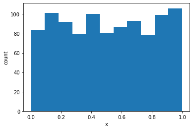

```python
plt.hist(xu_1000, bins=11)
plt.xlabel('x')
plt.ylabel('count')
plt.show()
```

```python
# if we wanted to use UNIFORM explicitly

random.seed(81)

xu_uniform = [ random.uniform(a=25, b=105) for _ in range(5000) ]
```

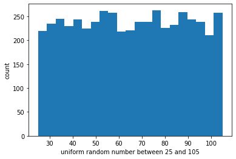

```python
plt.hist(xu_uniform, bins=21)
plt.xlabel('uniform random number between 25 and 105')
plt.ylabel('count')
plt.show()
```

```python
# matplotlib.pyplot.hist()
```

### Summarize our random samples

Calculate the min, max, and average of the 1000 random samples between 0 and 1.

```python
print( min(xu_1000) )

print( max(xu_1000) )

print( my_avg(xu_1000) )
```

```
0.0009142983879967259
0.9982826275179507
0.5077442149000129
```

```python
print( my_avg([random.random() for _ in range(10000)]) )
```

```
0.499876113483613
```

### POINT ESTIMATE

It does not say anything about the uncertainty in the estimate.

## SIMULATION

Use random samples to study the uncertainty of the sample average estimate.

We were performing 2 actions to calculate the sample average:

- Generate a random sequence from a specified distribution
- Calculate the sample average

```python
# define a function that executes the two steps described above

def gen_samples_calc_avg(N):
    """ assume we are using the random.random() """
    return my_avg( [random.random() for _ in range(N)] )
```

```python
print( my_avg(yu) )
```

```
0.5407598320800735
```

```python
random.seed(21)

gen_samples_calc_avg(7) == my_avg(yu)
```

```
True
```

Let's calculate the sample average MANY, MANY, MANY times.

```python
random.seed(51)

print( gen_samples_calc_avg(7) )

print( gen_samples_calc_avg(7) )

print( gen_samples_calc_avg(7) )

print( gen_samples_calc_avg(7) )
```

```
0.49128172289705047
0.6028632187643036
0.571620183697683
0.6356428162727541
```

### Calculate the sample average 1000 times

I will call this REPLICATE or REPEAT the sample average calculation.

```python
random.seed(101)

xbar_sim_N07_R1000 = [ gen_samples_calc_avg(7) for _ in range(1000) ]
```

```python
print( len(xbar_sim_N07_R1000) )
```

```
1000
```

### the average of the average

```python
print( my_avg(xbar_sim_N07_R1000) )
```

```
0.5045852639773879
```

```python
print( round( my_avg(xbar_sim_N07_R1000), 4) )
```

```
0.5046
```

### distribution of the averages

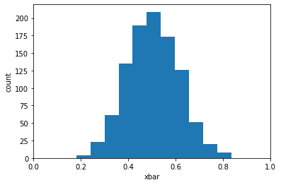

```python
plt.hist(xbar_sim_N07_R1000, bins=11)
plt.xlabel('xbar')
plt.ylabel('count')
plt.xlim(0, 1)
plt.show()
```

### Use more replications

```python
random.seed(101)

xbar_sim_N07_R1e4 = [ gen_samples_calc_avg(7) for _ in range(int(1e4)) ]
```

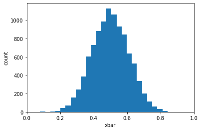

```python
plt.hist(xbar_sim_N07_R1e4, bins=25)
plt.xlabel('xbar')
plt.ylabel('count')
plt.xlim(0, 1)
plt.show()
```

```python
print( my_avg( xbar_sim_N07_R1e4) )
```

```
0.5007191489737309
```

### small number of replications

```python
random.seed(101)

xbar_sim_N07_R0015 = [ gen_samples_calc_avg(7) for _ in range(15) ]
```

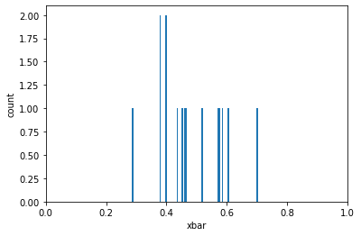

```python
plt.hist(xbar_sim_N07_R0015, bins=101)
plt.xlabel('xbar')
plt.ylabel('count')
plt.xlim(0, 1)
plt.show()
```

### repeat the replication process multiple times

Use different number of replications each time.

```python
num_replications = [ 5 * (2 ** ix) for ix in range(12) ]

print( num_replications )
```

```
[5, 10, 20, 40, 80, 160, 320, 640, 1280, 2560, 5120, 10240]
```

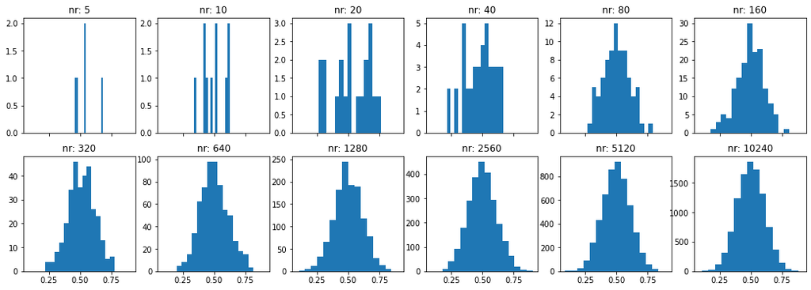

```python
fix, axs = plt.subplots(2, 6, figsize=(18, 6), sharex=True, sharey=False)

axs = axs.ravel()

random.seed(801)
for i, nr in enumerate(num_replications):
    axs[i].hist([gen_samples_calc_avg(7) for _ in range(nr)], density=False, bins=15)
    axs[i].set_title("nr: " + str(nr))
```

THIS IS THE CENTRAL LIMIT THEROEM (CLT) !!!!

We could talk about the central limit theorem in more detail here.

## Sample variance

$$ s^2 = \frac{1}{N - 1} \sum_{n=1}^{N} \left( \left( x_n - \bar{x} \right)^2 \right) $$

```python
# define a function to calculate the sample variance
def my_variance(x):
    xbar = my_avg(x)
    squared_deviation = [ (xn - xbar) ** 2 for xn in x ]
    return sum(squared_deviation) / ( len(x) - 1 )
```

```python
# check

print( my_variance([1, 2, 3])  )
```

```
1.0
```

```python
# check again

print( my_variance([5, 10, 15]))
```

```
25.0
```

```python
num_replications_study = [5 * (2 ** ix) for ix in range(16)]

print( max(num_replications_study))
```

```
163840
```

```python
print( num_replications_study )
```

```
[5, 10, 20, 40, 80, 160, 320, 640, 1280, 2560, 5120, 10240, 20480, 40960, 81920, 163840]
```

```python
# nested list comprehension

# build up the sequence of steps

# <output> = [ <variance per nr> for nr in num_replications_study ]

# the inner most operation

# <variance per nr> [ my_variance( [gen_samples_calc_avg(7) for _ in range(nr)] ) ]
```

```python
random.seed(9123)

study_variance_N07 = [ my_variance( [gen_samples_calc_avg(7) for _ in range(nr)] ) for nr in num_replications_study ]
```

```python
print( len(study_variance_N07) )
```

```
16
```

```python
print( study_variance_N07 )
```

[output not shown]

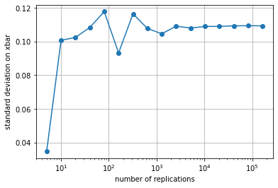

```python
# plot the results

fig, ax = plt.subplots()

ax.plot(num_replications_study, [ xv ** 0.5 for xv in study_variance_N07 ], '-o')
ax.set_xscale('log')
ax.set_xlabel('number of replications')
ax.set_ylabel('standard deviation on xbar')
ax.grid(True)
plt.show()
```